# Exercise 05

`## [[1]]`

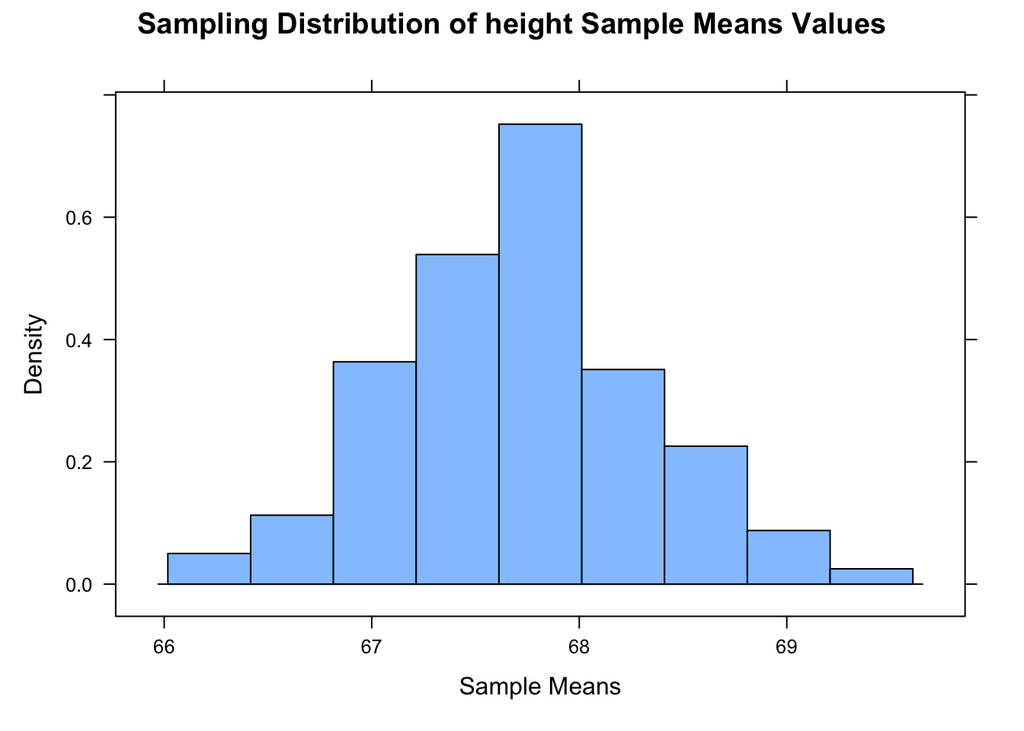

`## ## [[2]]`

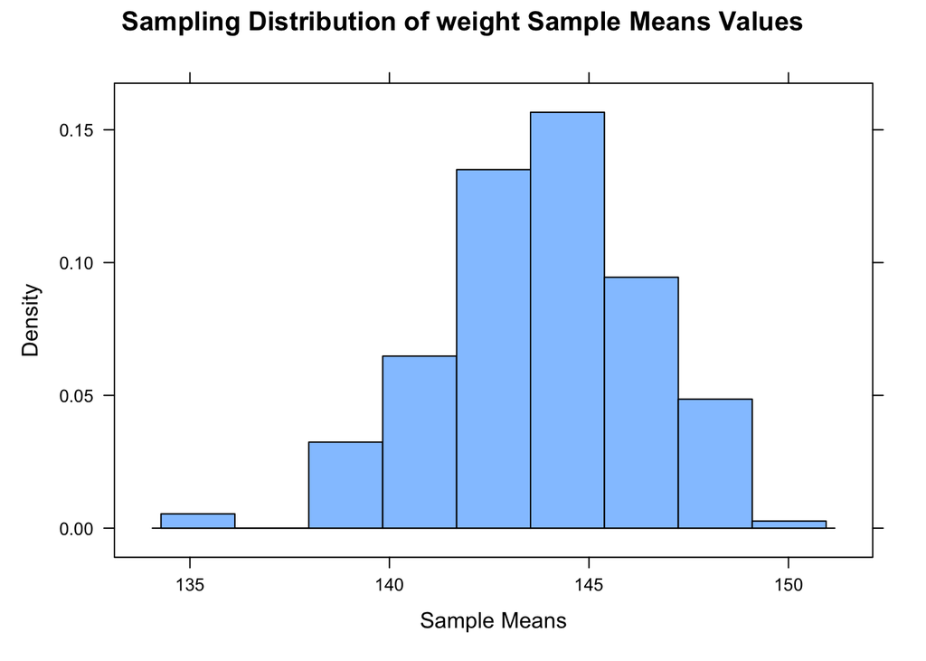

`## ## [[3]]`

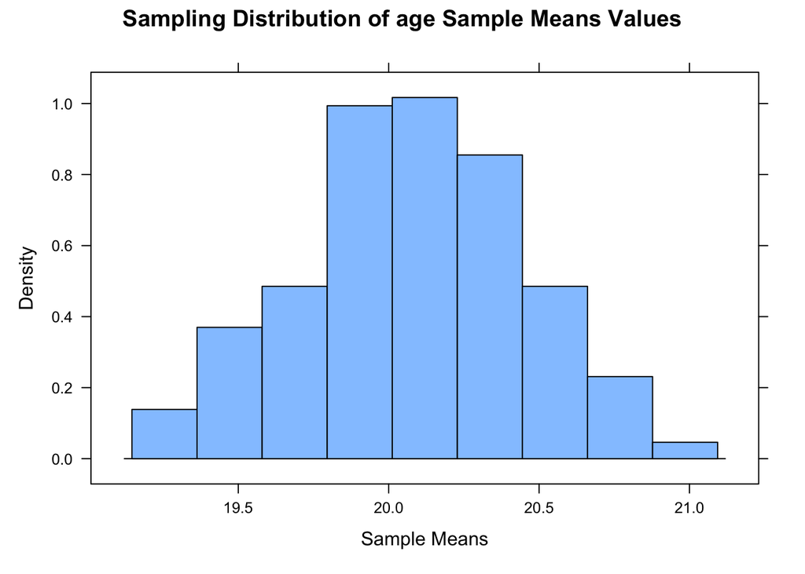

`## ## [[4]]`

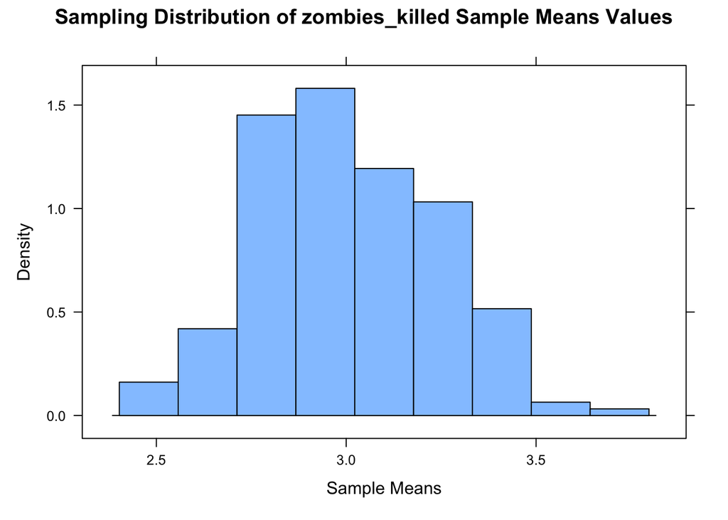

`## ## [[5]]`

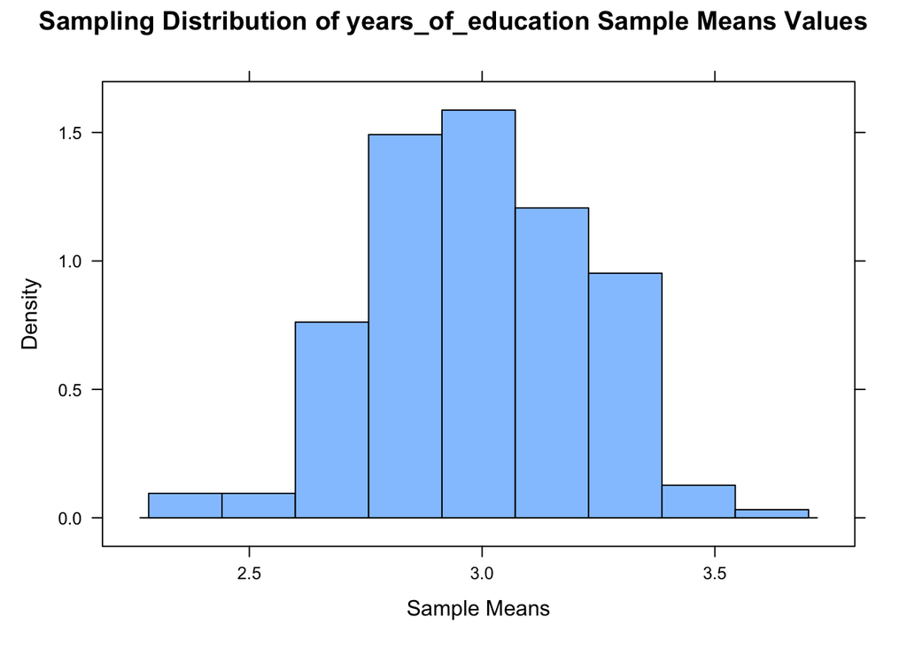

Step 9:

Construct a 95% confidence interval for each mean directly from the sampling distribution of sample means using the central 95% that distribution (i.e., by setting the lower and upper CI bounds to 2.5% and 97.5% of the way through that distribution).

HINT: You will want to use the quantile() function for this!

—> I found the instructions/examples for using the quanitle() function in Module 14, but I’m also using the R documentation for this function to customize it to my code:

https://www.rdocumentation.org/packages/stats/versions/3.6.2/topics/quantile

QUESTIONS:

- How do the various 95% CIs you estimated compare to one another (i.e., the CI based on one sample and the corresponding sample standard deviation versus the CI based on simulation where you created a sampling distribution across 200 samples)?

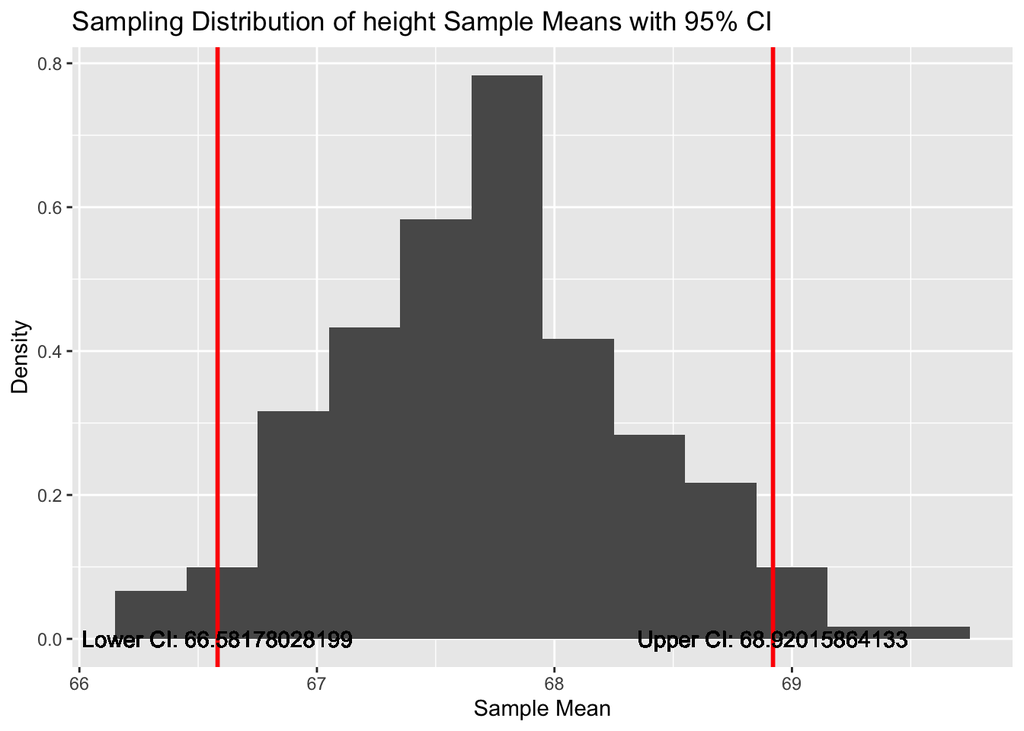

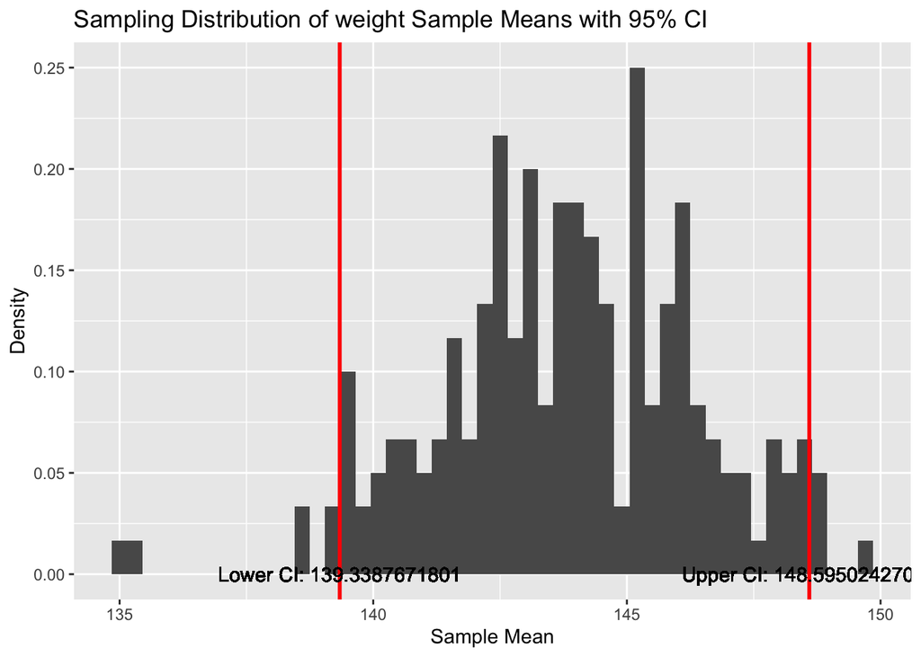

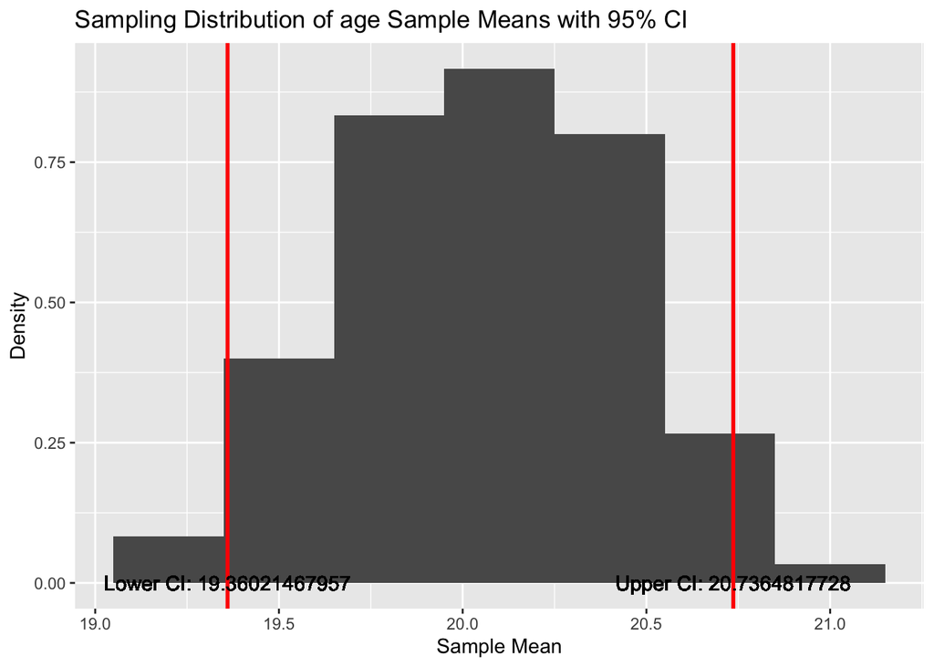

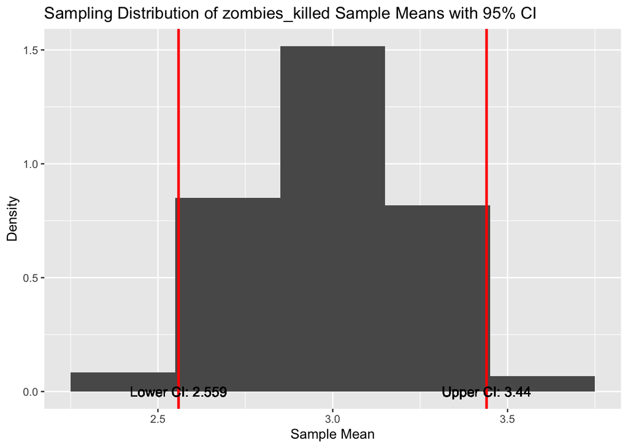

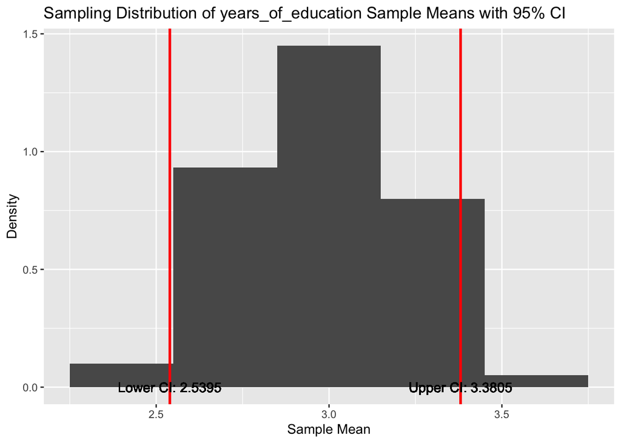

```r
# because I have multiple variables that each have their own mean sampling distributions, I'm using a for loop to apply the CI for each

# for a variable in the all_sample_means list from step 7
for(var_name in names(all_samples_means)) {
  # new dataframe to store all the sample means for each variable, just like in step 8, but putting it inside of this loop
  means_df <- data.frame(SampleMeanVal = all_samples_means[[var_name]])

  # the 95% CI for each will be centered around the mean of the sampling distribution
  # using the quantile() function here
  # drawing out the sample mean values from the means_df dataframe made in the previous step
  # using the probs = c() notation as used in the R documentation, here I can set my interval
  ci <- quantile(means_df$SampleMeanVal, probs = c(0.025, 0.975))

  # for the CI's I felt that ggplot was a little easier for me to use
  p <- ggplot(means_df, aes(x = SampleMeanVal)) +
    # binwidth was a little tricky, but 0.4 seemed to be the best once to display all the variables
    geom_histogram(aes(y = ..density..), binwidth = 0.3) +
    # before, I entered the CI bounds as a vector with the lower limit first, then upper
    # now I can use the index of those items to plot the lower and upper CI bound
    geom_vline(xintercept = ci[1], color = "red", size = 1) + # lower limit
    geom_vline(xintercept = ci[2], color = "red", size = 1) + # upper limit

    #also ended up using geom_text to print out the actual numeric values of the CI
    geom_text(aes(x = ci[1], y = 0, label = paste("Lower CI:", ci[1]))) +
    geom_text(aes(x = ci[2], y = 0, label = paste("Upper CI:", ci[2]))) +
    labs(title = paste("Sampling Distribution of", var_name, "Sample Means with 95% CI"),
         x = "Sample Mean", y = "Density")
    print(p)
}
```

Step 10:

- use bootstrapping to generate a 95% confidence interval for each variable mean
- this time resample 1000 samples, WITH replacement, from original sample

(i.e., by setting the lower and upper CI bounds to 2.5% and 97.5% of the way through the sampling distribution generated by bootstrapping).

following the same {infer} method from Module 16 that I used in Challenge 1, but with the addition of finding the Confidence Interval

for that I am using the get_confidence_interval() function: https://www.rdocumentation.org/packages/infer/versions/0.5.4/topics/get_confidence_interval

```r
# creating an empty list to store the CI's after bootstrapping
bootstrap_CIs <- list()

# clarifying the variable names
# even though I'm not using the sample set, the variable names are still the same
variables <- names(all_samples_means)

# for a given variable in this each iteration of this loop...
for(var_name in variables) {
  # I need to convert the data into
  sample_data <- data.frame(sample_means = all_samples_means[[var_name]])

  # I need to get my bootstrapped samples from the ORIGINAL DATASET, z
  bootstrap_results <- z %>%
    # multiple variables of interest to specify
    # so instead of have response = to a single variable, I'm saying that the input will be each variable, for the respective iteration of the loop
    specify(response = !!sym(var_name)) %>%
    # 1000 bootstrapped samples
    generate(reps = 1000, type = "bootstrap", size=50, replace=TRUE ) %>%
    # I need the mean to determine the CI
    calculate(stat = "mean") %>%
    # now I can use the get_confidence_interval() to easily get the 95% CI
    get_confidence_interval(level = 0.95, type = "percentile")

  # finally I can store the results in the empty bootstrap_CIs list from before
  bootstrap_CIs[[var_name]] <- bootstrap_results
}


print(bootstrap_CIs)
```

```
## $height
## # A tibble: 1 × 2
##   lower_ci upper_ci
##      <dbl>    <dbl>
## 1     67.4     67.9
##
## $weight
## # A tibble: 1 × 2
##   lower_ci upper_ci
##      <dbl>    <dbl>
## 1     143.     145.
##
## $age
## # A tibble: 1 × 2
##   lower_ci upper_ci
##      <dbl>    <dbl>
## 1     19.9     20.2
##
## $zombies_killed
## # A tibble: 1 × 2
##   lower_ci upper_ci
##      <dbl>    <dbl>
## 1     2.88     3.10
##
## $years_of_education
## # A tibble: 1 × 2
##   lower_ci upper_ci
##      <dbl>    <dbl>
## 1     2.89     3.10
```